# act_report

## Data Analysis

|  | favorite_count | retweet_count | tweet_id | timestamp | source | text | rating_numerator | rating_denominator | name | doggo | floofer | pupper | puppo | jpg_url | img_num | breed |
| --- | --- | --- | --- | --- | --- | --- | --- | --- | --- | --- | --- | --- | --- | --- | --- | --- |
| 0 | 35481 | 7494 | 892420643555336193 | 2017-08-01 16:23:56+00:00 | http://twitter.com/download/iphone | This is Phineas. He's a mystical boy. Only eve... | 13.0 | 10.0 | Phineas | 0 | 0 | 0 | 0 | https://pbs.twimg.com/media/DGKD1-bXoAAIAUK.jpg | 1 | orange |
| 1 | 30714 | 5562 | 892177421306343426 | 2017-08-01 00:17:27+00:00 | http://twitter.com/download/iphone | This is Tilly. She's just checking pup on you.... | 13.0 | 10.0 | Tilly | 0 | 0 | 0 | 0 | https://pbs.twimg.com/media/DGGmoV4XsAAUL6n.jpg | 1 | chihuahua |

First we find out the most posted 30 breeds on @WeRateDog tweet account, and then we analyst these 30 breeds.  
top 30 breeds:  
'golden retriever', 'labrador retriever', 'pembroke', 'chihuahua', 'pug', 'toy poodle', 'chow', 'samoyed', 'pomeranian', 'malamute', 'french bulldog', 'cocker spaniel', 'chesapeake bay retriever', 'miniature pinscher', 'eskimo dog', 'cardigan', 'german shepherd', 'shih-tzu', 'siberian husky', 'staffordshire bullterrier', 'beagle', 'shetland sheepdog', 'maltese dog', 'kuvasz', 'rottweiler', 'basset', 'lakeland terrier', 'italian greyhound', 'west highland white terrier', 'soft-coated wheaten terrier'

And when we got the top 30 breed, we could draw popularity metrics from the favorite count, retweet count, ranting for these breeds.

The tweets of french bulldog get average 18414 favorites, which makes the bulldog become the top 1 breed getting favorites and a big lead to the other breeds. And the second lead getting 12417 favoraites is cocker spaniel. *(see below pic 'avg favorite_count for top 30 breed')*

Similar as retweet count, The tweets of french bulldog get average 4694 retweets, which makes the bulldog become the top 1 breed getting retweets. And the second lead getting 4271 retweets is cocker spaniel. *(see below pic 'avg retweet_count for top 30 breed')*

For rating for top 30 breed, I calculate the average rating by dividing average rating numerator by average rating denominator. Among the 30 breeds, the average rating ranges from 0.97 to 1.17. So general speaking, all dog got decent rating. When we look closely, samoyed gets the highest rating of 1.17, and maltese dog gets lowest rating of 0.97.

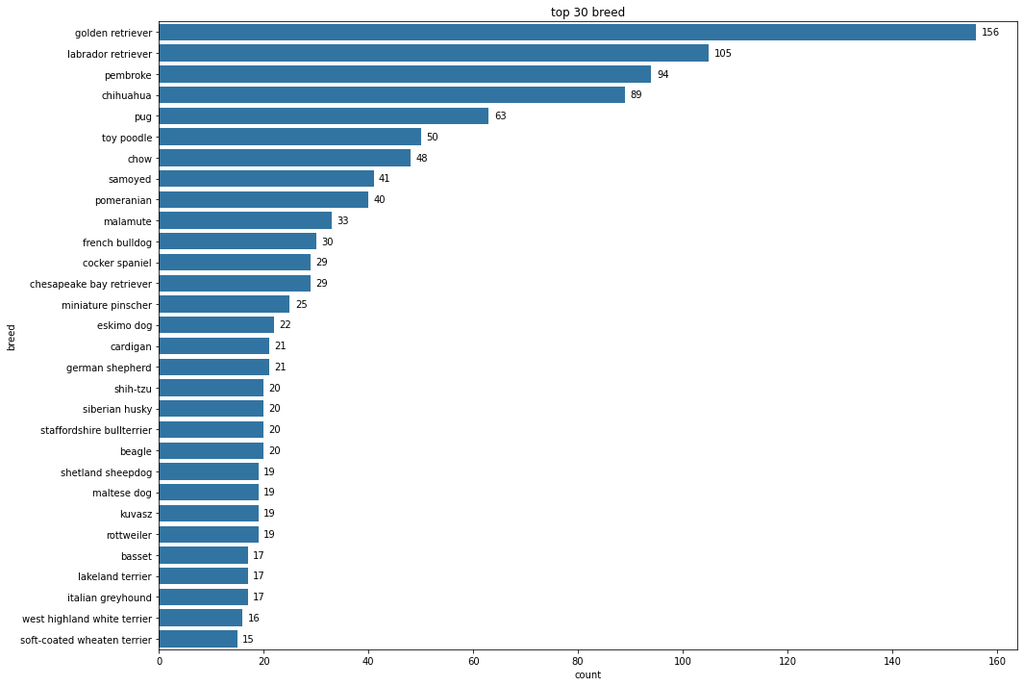

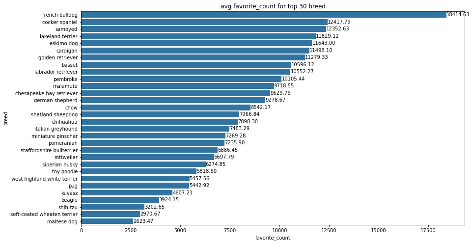

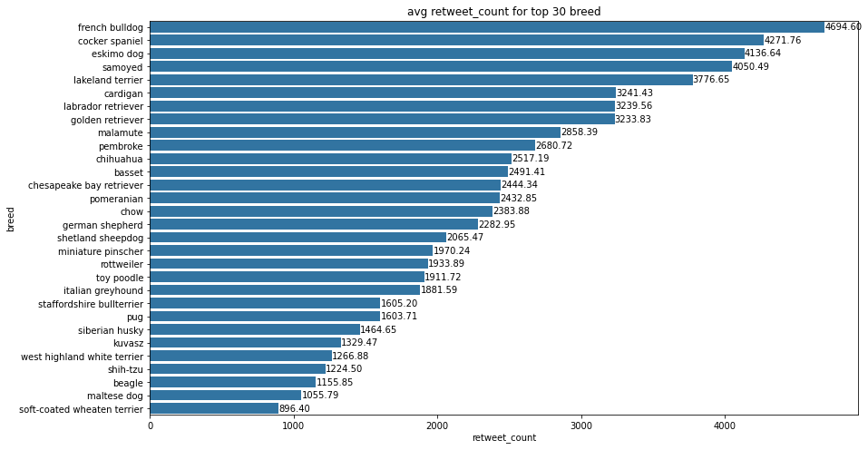

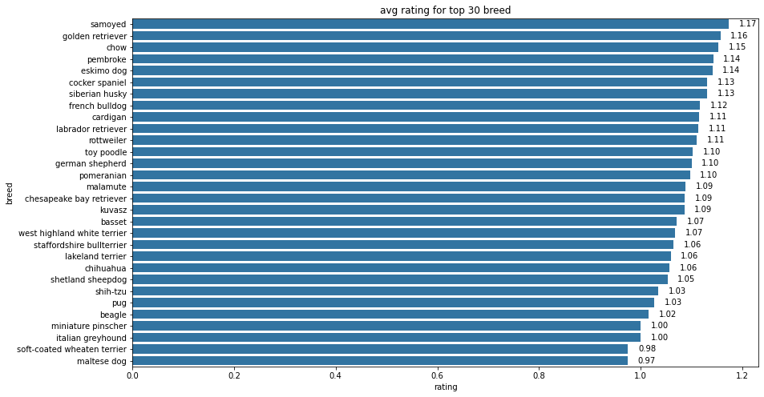

#### Question 2: Twitter Analyics -- Twitter account development

From the number of tweets posted on the @WeRateDog account, these is a peak around end of 2015, then the posts decrease next several months, and then gets relatively stational post number after April 2016.

For number of favorites, we could tell the favorites increase from Jan 2016 to June 2017, and get a shape drop after June 2017.

For number of retweet, it shows the retweet gets its peak around the end of 2015, and then get a small peak around May 2016 and Jan 2017.

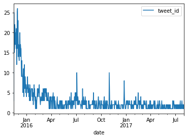

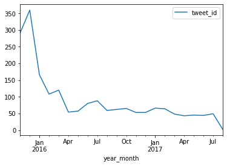

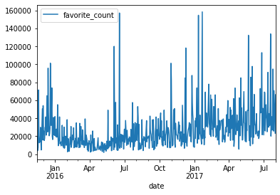

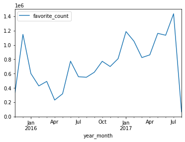

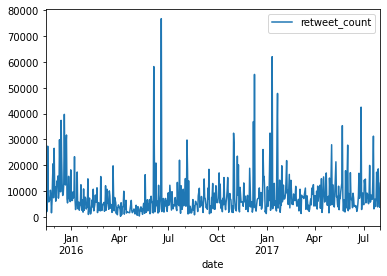

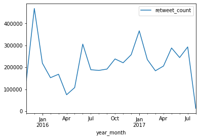

#### Q3: What are popular names people would get to their dog ?

The most common name people gave to their dogs are Copper, Charlie and Oliver, Then Tucker, lucy, Penny are the second tier.

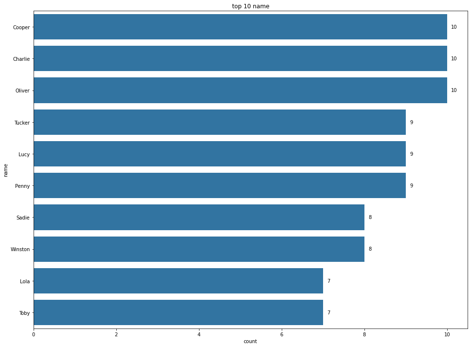

[output not shown]